# FarmHack 2023: Crushable Depth

## Time Series Dissection: Clustering, Classification, Seasonality and Outlier Detection

(Back to top)  
THe informed decision we took during imputing our data, that farms of the same location should behave similarly, was empirically verified by looking at the amount of variability within a location. This was done rather primitively: by simply looking at the amount of unique values reported from each location for certain measurements in relation to the total number values for that location. The rationale was that if 19 farms from location *A* report hourly, every day, such that they have 8,784 records at the end of a year, but they also only report 27 distinct values of temperature throughout the year, it means that the temperature throughout the year varies only by $\frac{27}{8784} = 0.30\%$ for the entire year. Conversely if those farms report 5,874 unique values for wind direction within the year, it means that almost every day has a new and different direction for the wind giving us a variability of $~67\%$. Our overall measurement of climactic variability is included in the associated spreadsheet for this project; the calculation was performed in SQL and results exported.

However while this seemed to be a decent approach, it wasn't deeply verified. The going idea here is to employ a clustering algorithm that's specifically desinged for working with time series, such as Dynamic Time Warping, Longest Common Subsequences, Fourier Transformations, SVD, Independent Component Analysis, etc.; and verify whether the number of clusters we receive are in consonance with the number of locations we have, within a certain margin of error. This way, we can be certain that farms of the same location behave in a similar fashion owing to the impact of climate, and it would also answer another assumption of our work so far: that corporations are not as dissimilar as they seem to be, because even though they might use different cropping techniques or fertilisers for better yields, their strategy is still dependent on the environment and therefore their differentiation is limited.

### Dynamic Time Warping

(Back to top)  
At it's core, what DTW does is best explained in relation to the approach taken by standard Euclidean clustering. Euclidean distances on a time series dataset measure the distance between each data point occurring at that time; in other words, if we have two time series *A* and *B* with row indices $i\dots n$, then Euclidean distances would only measure $\sqrt{(A_i - B_i)^2}$. In contrast, Dynamic Time Warping calculates an "optimal match" between two given time series with certain restrictions:

- Every index from the first sequence must be matched with one or more indices from the other sequence, and vice-versa
- The first index from the first sequence must be matched with the first index from the other sequence (but it does not have to be its only match)
- The last index from the first sequence must be matched with the last index from the other sequence (but it does not have to be its only match)
- The mapping of the indices from the first sequence to indices from the other sequence must be monotonically increasing, and vice versa, i.e. if $j > i$ are indices from the first sequence, then there must not be two indices $l > k$ in the other sequence, such that index $i$ is matched with index $l$ and index $j$ is matched with index $k$, or vice-versa. In ot her words, you cannot have a point in time from A, say at time $t = 7$ match with a point from B that's at $t = 9$ while A at $t = 8$ matches with B at $t = 6$. You cannot have crossing "lines".

The "optimal match" is the one that satisfies all restrictions with the minimal cost, where the cost is computed as the sum of absolute differences (i.e. $\sum{|A_i - B_i|}$), for each matched pair of indices, between their values. Such computation also lends itself well to being aware of the different phases of the involved series. This approach is perhaps best explained with a picture, neatly depicted by [Heka.AI in their very effective article on Time Series Clustering](https://www.heka.ai/en/our-publications/time-series-clustering):

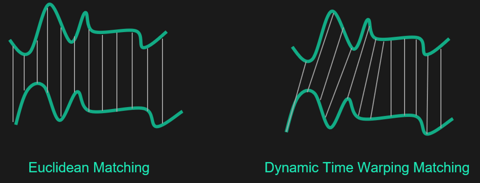

*Source: Heka.ai: Time Series Clustering*

In fact, DTW has been used across financial applications in order to deterministically model behaviour that's superficially chaotic to good results. Clustering our farms together would not only have shown us whether our idea of locations behaving similarly is indeed true, it also would have allowed us to more confidently subsample our dataset such that we pick $n$ farms that best represent their cluster, for which again we could use DTW on the farm of choice against the average temporal behaviour of the cluster. Additionally, like many other clustering approaches, it would help us identify farms that are outliers on top of other powerful temporal anomaly detection algorithms.

### Longest Common Subsequences

(Back to top)  
Another flexible method of time series clustering that adapts well to noisy series and is also "multivariate" is the LCS, which when given two sequences *X* and *Z*, says that *Z* is a subsequence of *X* if removing some elements from *X* produces *Z*. Quite simple and straightforward, and can be adapted to multivariate comparisons such as comparing *X*, *Y* and *Z* together to find a common subsequence. The longest subsequence between *X* and *Z* is the longest common subsequence: $nLCS = \frac{length(LCS)}{\sqrt{m \cdot n}}$. To find the longest subsequences common to $X_i$ and $Y_j$, compare the elements $x_i$ and $y_j$. If they are equal, then the sequence $LCS(X_{i-1}; Y_{j-1})$ is extended by that element, $x_i$. If they are not equal, then the longer of the two sequences, $LCS(X_i; Y_{j-1})$ /, and $LCS(X_{i-1}; Y_j)$ /, is retained. (If they are both the same length, but not identical, then both are retained.) However, the LCS is a dynamic algorithm and therefore is not particularly efficient.

### Singular Value Similarity

(Back to top)  
Specially proposed in *Outlier Detection for Temporal Data by Gupta et. al.* which is quoted here because the explanation is just too juicy: *"Consider two multi-variate time series* $M_a$ *and* $M_b$. *Let the time series be defined over time intervals of length* $l_1$ *and* $l_2$ , *respectively. Thus, the multi-variate time series can be represented using matrices* $M_{a}^{l_1 \times c}$ *and* $M_{b}^{l_2 \times c}$ *respectively, where* $c$ *is the number of metric variables. For both the matrices, we can compute the top* $k$ *principal components (that can capture* $>95%$ *variance) to obtain smaller subspaces* $P^{c \times k}$ *and* $Q^{c \times k}$, *respectively. Similarity between the two multi-variate time series can be expressed in terms of the similarity between their principal components as the average sum of squares of the cosines of the angles between each principal component in* $P$ *and* $Q$." This can even be adapted to a weighted average which shows the amount of variance explained by each principal component, and is probably the easiest algorithm out of the ones discussed so far.

### Seasonality

(Back to top)  
The methods discussed thus far, if implemented, would make the data going into our TFT much cleaner and easier to handle, not to mention smaller and therefore quicker to chew through. Another common analytical approach for time series is using a simple Fourier decomposition across all of our series to determine if we have a seasonal effect or not:

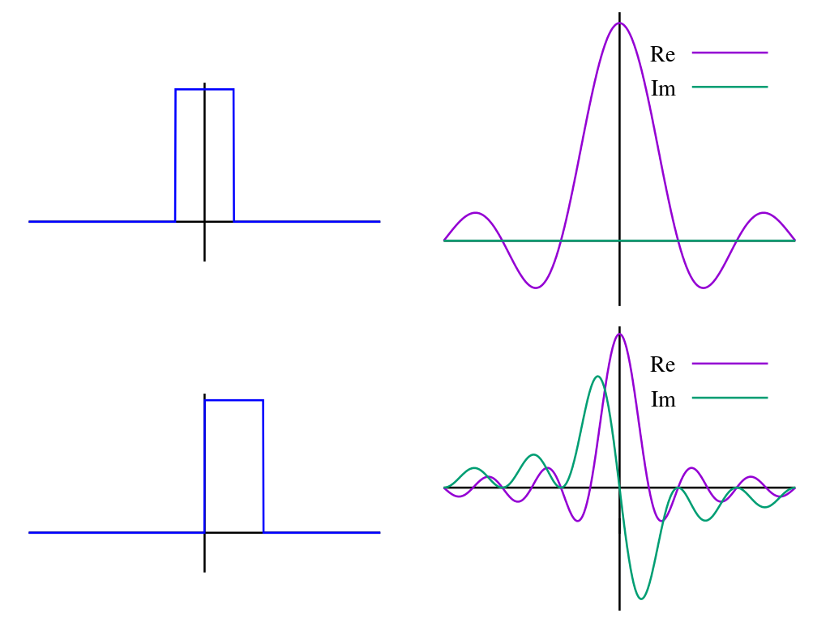

*Source: Sławomir_Biały; Wikipedia Commons, Fourier Transform*

Internally the TFT does perform something similar, but we don't need an especially complex algorithm to run on a GPU when we have something much simpler, and that can also detect multiple seasonal effects within a series. In fact, most of the methods here can be combined, for example we can cluster farms together and run inference to verify whether the clustering algorithm has retained some of the constituent's farms most important (largest Fourier values) seasonal effects such that it best represents the behaviour of the cluster or not.

Sources:

- Orlando, G., Bufalo, M. & Stoop, R. · Financial markets’ deterministic aspects modeled by a low-dimensional equation. Sci Rep 12, 1693 (2022). https://doi.org/10.1038/s41598-022-05765-z
- Manish Gupta, Jing Gao, Charu Aggarwal, Jiawei Han · Outlier Detection for Temporal Data
- Ali Alqahtani, Mohammed Ali, Xianghua Xie and Mark W. Jones · Deep Time-Series Clustering: A Review; Electronics 2021, 10(23), 3001; https://doi.org/10.3390/electronics10233001
- [YouTube: 3Blue1Brown; But What Is a Fourier Transform?](https://www.youtube.com/watch?v=spUNpyF58BY)
- [Wikipedia: Dynamic Time Warping](https://en.wikipedia.org/wiki/Dynamic_time_warping)
- Denyse; [TowardsDataScience: Time Series Clustering and Classification — Deriving Trends and Archetypes from Sequential Data](https://towardsdatascience.com/time-series-clustering-deriving-trends-and-archetypes-from-sequential-data-bb87783312b4)
- Zijing Zhu; [TowardsDataScience: Taking Seasonality into Consideration for Time Series Analysis](https://towardsdatascience.com/taking-seasonality-into-consideration-for-time-series-analysis-4e1f4fbb768f)